# ANOVA_part_2_lab_script

Andrew Stewart

22/11/2018

First we need to load our packages - tidyverse, afex, and psych.

```r
library(tidyverse)
library(afex)
library(psych)
library(emmeans)
```

The datafile is called ANOVA_lab2_data1.csv. We need to load our dataset and map it onto a variable we’re calling ‘data’.

```r
data <- read_csv("ANOVA_lab2_data1.csv")
```

The data are from a 2 x 2 x 3 mixed design experiment where we measured people’s response times to maths questions that were either Easy or Hard, and to which they had to respond either under Time Pressure or under No Time Pressure. These are our first two factors and are repeated measures (i.e., everyone saw all 4 conditions). Our final factor is between subjects and corresponds to whether our participants were in one of three groups. The groups were Psychology Students, Maths Students, and Arts Students. We want to know where a participant’s perfomance on the maths questions under time pressure vs. not under time pressure is influenced by which one of these three groups they belong to. Conduct the appropriate ANOVA to answer this question.

Our data look like this:

```r
data
```

```
## # A tibble: 288 x 5
##    Subject Difficulty Time_Pressure    RT Group
##      <int> <chr>      <chr>         <int> <chr>
##  1       1 Easy       Pressure        855 Psychology_Students
##  2       2 Easy       Pressure        956 Psychology_Students
##  3       3 Easy       Pressure       1038 Psychology_Students
##  4       4 Easy       Pressure        827 Psychology_Students
##  5       5 Easy       Pressure       1029 Psychology_Students
##  6       6 Easy       Pressure       1004 Psychology_Students
##  7       7 Easy       Pressure       1012 Psychology_Students
##  8       8 Easy       Pressure       1167 Psychology_Students
##  9       9 Easy       Pressure        817 Psychology_Students
## 10      10 Easy       Pressure       1190 Psychology_Students
## # ... with 278 more rows
```

Let’s set our three IV columns as factors and look at our data again - note the three columns are now recognised as factors.

```r
data$Difficulty <- as.factor(data$Difficulty)
data$Time_Pressure <- as.factor(data$Time_Pressure)
data$Group <- as.factor(data$Group)
data
```

```
## # A tibble: 288 x 5
##    Subject Difficulty Time_Pressure    RT Group
##      <int> <fct>      <fct>         <int> <fct>
##  1       1 Easy       Pressure        855 Psychology_Students
##  2       2 Easy       Pressure        956 Psychology_Students
##  3       3 Easy       Pressure       1038 Psychology_Students
##  4       4 Easy       Pressure        827 Psychology_Students
##  5       5 Easy       Pressure       1029 Psychology_Students
##  6       6 Easy       Pressure       1004 Psychology_Students
##  7       7 Easy       Pressure       1012 Psychology_Students
##  8       8 Easy       Pressure       1167 Psychology_Students
##  9       9 Easy       Pressure        817 Psychology_Students
## 10      10 Easy       Pressure       1190 Psychology_Students
## # ... with 278 more rows
```

We are first going to visualise the whole dataset (ignoring the Group factor initially). We will construct a boxplot first.

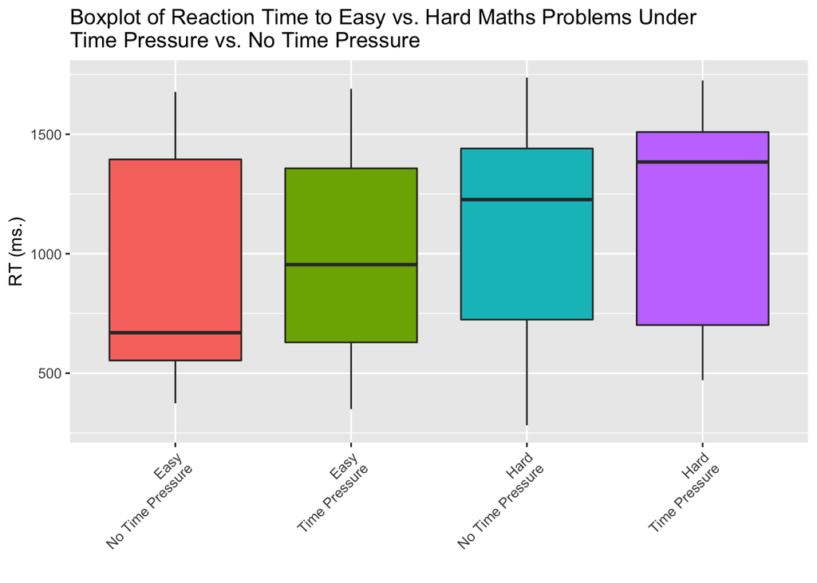

```r
ggplot(data, aes(x = Difficulty:Time_Pressure, y = RT, fill = Difficulty:Time_Pressure)) +
  geom_boxplot() +
  guides(fill = FALSE) +
  theme(axis.text.x = element_text(angle = 45, hjust = 1)) +
  scale_x_discrete(labels = c("Easy\nNo Time Pressure","Easy\nTime Pressure", "Hard\nNo Time Pressure", "Hard\nTime Pressure")) +
  labs(x = "", y = "RT (ms.)", title = "Boxplot of Reaction Time to Easy vs. Hard Maths Problems Under\nTime Pressure vs. No Time Pressure")
```

Now we are going ot plot the condition means with 95% confidence intervals.

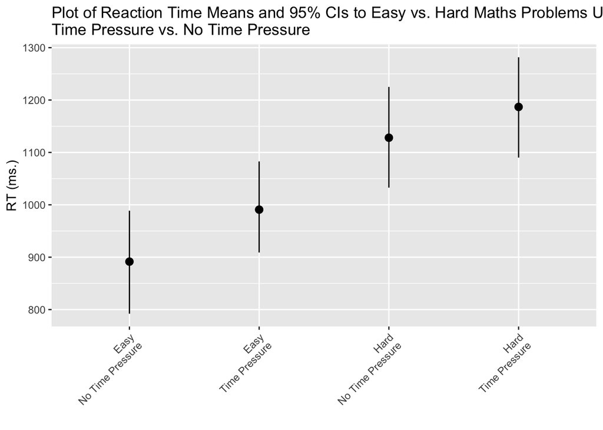

```r
ggplot(data, aes(x = Difficulty:Time_Pressure, y = RT, fill = Difficulty:Time_Pressure)) +
  stat_summary(fun.data = mean_cl_boot) +
  guides(fill = FALSE) +
  theme(axis.text.x = element_text(angle = 45, hjust = 1)) +
  scale_x_discrete(labels = c("Easy\nNo Time Pressure","Easy\nTime Pressure","Hard\nNo Time Pressure", "Hard\nTime Pressure")) +
  labs(x = "", y = "RT (ms.)", title = "Plot of Reaction Time Means and 95% CIs to Easy vs. Hard Maths Problems Under\nTime Pressure vs. No Time Pressure")
```

These plots are potentially quite mislading. The boxplot might make use think our data overlap quite a lot from one Condition to the next, while the Means and CI plot might make us think that all conditions differ from each other (regardless of Group). But that’s because the distribution of the dataset is invisible to us via these visualisations. If we add the actual data we can see how misleading these kind of summary plots can be - we can colour the indiviudal data points by Group.

First we will redo our boxplot.

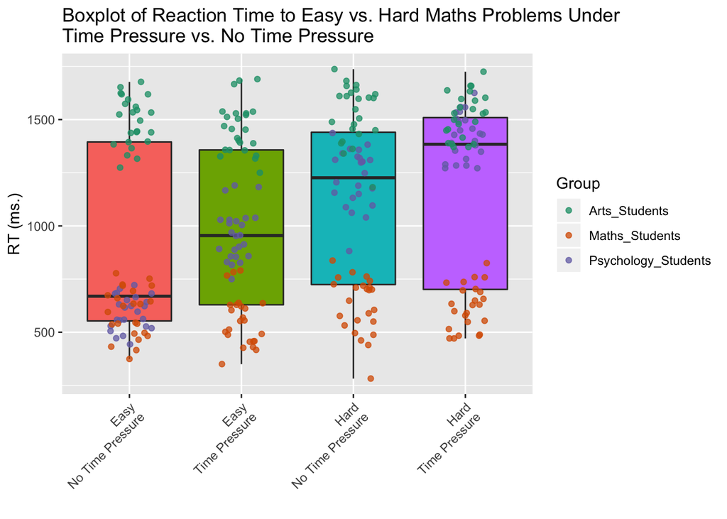

```r
ggplot(data, aes(x = Difficulty:Time_Pressure, y = RT, fill = Difficulty:Time_Pressure)) +
  geom_boxplot() + geom_jitter(aes(colour = Group), width = .2, alpha = .75) +
  guides(fill = FALSE) + scale_color_brewer(palette = "Dark2") +
  theme(axis.text.x = element_text(angle = 45, hjust = 1)) +
  scale_x_discrete(labels = c("Easy\nNo Time Pressure","Easy\nTime Pressure","Hard\nNo Time Pressure", "Hard\nTime Pressure")) +
  labs(x = "", y = "RT (ms.)", title = "Boxplot of Reaction Time to Easy vs. Hard Maths Problems Under\nTime Pressure vs. No Time Pressure")
```

Then we will redo our plot with means and 95% CIs.

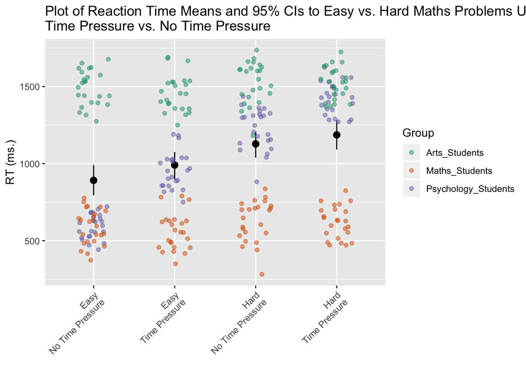

```r
ggplot(data, aes(x = Difficulty:Time_Pressure, y = RT, fill = Difficulty:Time_Pressure)) +
  stat_summary(fun.data = mean_cl_boot) + geom_jitter(aes(colour = Group), width = .2, alpha = .5) +
  guides(fill = FALSE) + scale_color_brewer(palette = "Dark2") +
  theme(axis.text.x = element_text(angle = 45, hjust = 1)) +
  scale_x_discrete(labels = c("Easy\nNo Time Pressure","Easy\nTime Pressure","Hard\nNo Time Pressure", "Hard\nTime Pressure")) +
  labs(x = "", y = "RT (ms.)", title = "Plot of Reaction Time Means and 95% CIs to Easy vs. Hard Maths Problems Under\nTime Pressure vs. No Time Pressure")
```

It is interesting to note that for the Easy / No Time Pressure Condition, the mean of the datset is nowhere near any of the actual data points - the 95% CI doesn’t include even one actual data point. It’s better that we do separate plots for each group. We are going to use the facet_wrap() function to generate separate plots for each Group.

Note that for this first plot I am flipping the x- and y- axes using coord_flip(). This can sometimes help with the interpretation of a visualisation (especially if the x-axis factor labels are quite long).

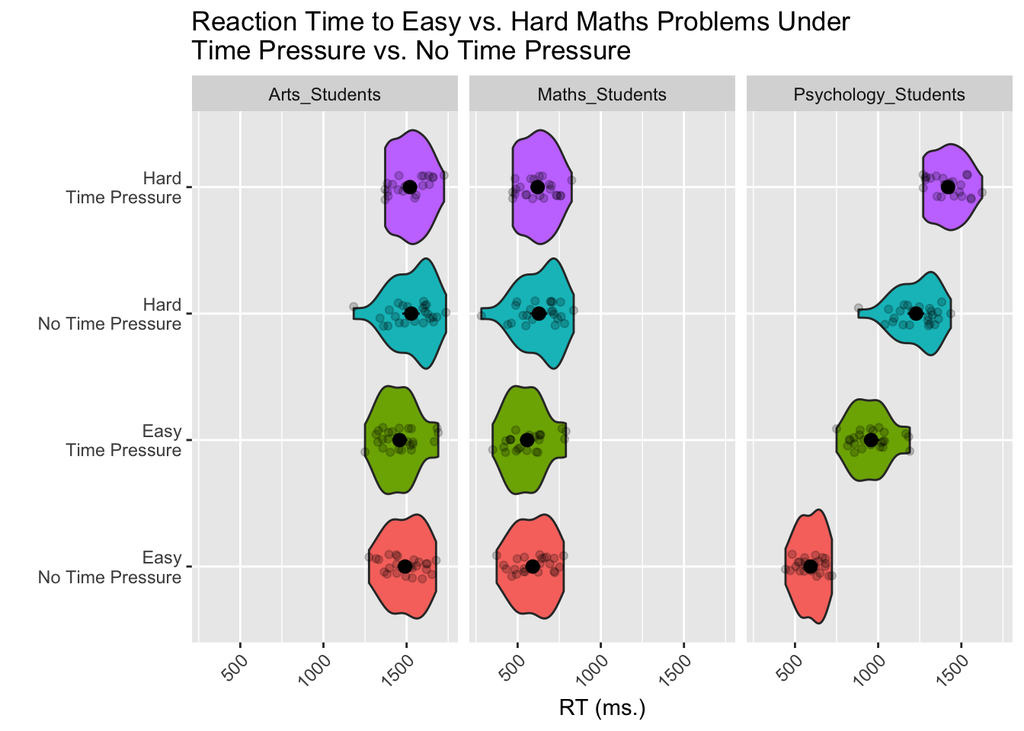

```r
ggplot(data, aes(x = Difficulty:Time_Pressure, y = RT, fill = Difficulty:Time_Pressure)) +
  facet_wrap(~ Group) +
  geom_violin() + geom_jitter(width = .1, alpha = .2) +
  stat_summary(fun.data = mean_cl_boot) + guides(fill = FALSE) +
  theme(axis.text.x = element_text(angle = 45, hjust = 1)) +
  scale_x_discrete(labels = c("Easy\nNo Time Pressure","Easy\nTime Pressure","Hard\nNo Time Pressure", "Hard\nTime Pressure")) +
  labs(x = "", y = "RT (ms.)", title = "Reaction Time to Easy vs. Hard Maths Problems Under\nTime Pressure vs. No Time Pressure") +
  coord_flip()
```

And now a boxplot - this time I’m not flipping the axes, but I am tilting the x-axis text 45 degrees to improve readibility.

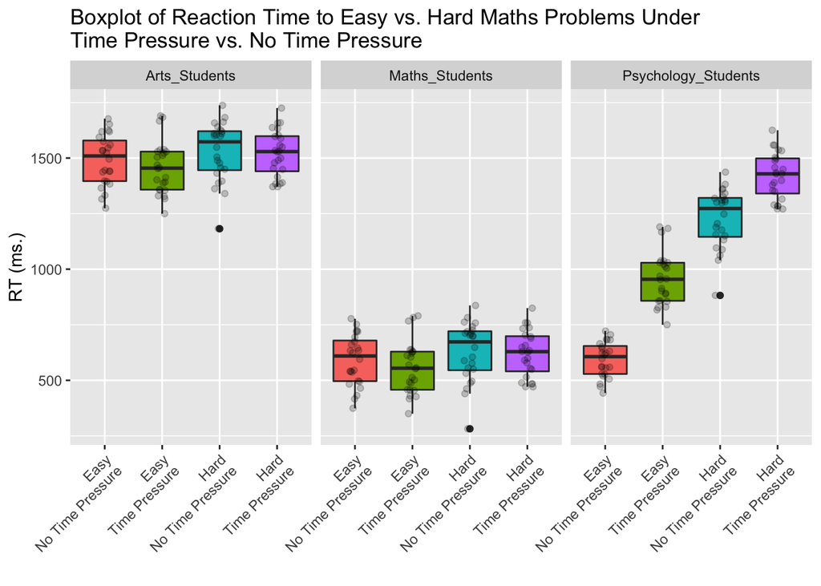

```r
ggplot(data, aes(x = Difficulty:Time_Pressure, y = RT, fill = Difficulty:Time_Pressure)) +
  facet_wrap(~ Group) +
  geom_boxplot() + geom_jitter(width = .1, alpha = .2) +
  guides(fill = FALSE) +
  theme(axis.text.x = element_text(angle = 45, hjust = 1)) +
  scale_x_discrete(labels = c("Easy\nNo Time Pressure","Easy\nTime Pressure","Hard\nNo Time Pressure", "Hard\nTime Pressure")) +
  labs(x = "", y = "RT (ms.)", title = "Boxplot of Reaction Time to Easy vs. Hard Maths Problems Under\nTime Pressure vs. No Time Pressure")
```

We are now going to generate some summary descriptives using the psych and tidyverse methods.

```r
describeBy(data$RT, group = list(data$Difficulty, data$Time_Pressure, data$Group))
```

```
##
##  Descriptive statistics by group
## : Easy
## : NoPressure
## : Arts_Students
##    vars  n    mean     sd median trimmed    mad  min  max range  skew
## X1    1 24 1490.58 114.17 1509.5 1492.75 143.81 1274 1677   403 -0.15
##    kurtosis   se
## X1    -1.21 23.3
## --------------------------------------------------------
## : Hard
## : NoPressure
## : Arts_Students
##    vars  n    mean     sd median trimmed    mad  min  max range  skew
## X1    1 24 1528.04 133.11   1573  1536.6 128.99 1182 1737   555 -0.65
##    kurtosis    se
## X1    -0.24 27.17
## --------------------------------------------------------
## : Easy
## : Pressure
## : Arts_Students
##    vars  n    mean     sd median trimmed    mad  min  max range skew
## X1    1 24 1457.42 118.33 1454.5  1451.9 116.38 1250 1690   440 0.39
##    kurtosis    se
## X1    -0.71 24.15
## --------------------------------------------------------
## : Hard
## : Pressure
## : Arts_Students
##    vars  n    mean     sd median trimmed   mad  min  max range skew
## X1    1 24 1520.17 104.05   1529  1517.9 114.9 1371 1725   354 0.09
##    kurtosis    se
## X1    -1.19 21.24
## --------------------------------------------------------
## : Easy
## : NoPressure
## : Maths_Students
##    vars  n   mean     sd median trimmed    mad min max range  skew
## X1    1 24 590.58 114.17  609.5  592.75 143.81 374 777   403 -0.15
##    kurtosis   se
```

[output cut: 42 more lines]

```
## : Easy
## : Pressure
## : Psychology_Students
##    vars  n   mean     sd median trimmed    mad min  max range skew
## X1    1 24 957.42 118.33  954.5   951.9 116.38 750 1190   440 0.39
##    kurtosis    se
## X1    -0.71 24.15
## --------------------------------------------------------
## : Hard
## : Pressure
## : Psychology_Students
##    vars  n    mean     sd median trimmed   mad  min  max range skew
## X1    1 24 1420.17 104.05   1429  1417.9 114.9 1271 1625   354 0.09
##    kurtosis    se
## X1    -1.19 21.24
```

```r
data %>% group_by(Group, Difficulty, Time_Pressure) %>% summarise(mean(RT), sd(RT))
```

```
## # A tibble: 12 x 5
## # Groups:   Group, Difficulty [?]
##    Group               Difficulty Time_Pressure `mean(RT)` `sd(RT)`
##    <fct>               <fct>      <fct>              <dbl>    <dbl>
##  1 Arts_Students       Easy       NoPressure         1491.    114.
##  2 Arts_Students       Easy       Pressure           1457.    118.
##  3 Arts_Students       Hard       NoPressure         1528.    133.
##  4 Arts_Students       Hard       Pressure           1520.    104.
##  5 Maths_Students      Easy       NoPressure          591.    114.
##  6 Maths_Students      Easy       Pressure            557.    118.
##  7 Maths_Students      Hard       NoPressure          628.    133.
##  8 Maths_Students      Hard       Pressure            620.    104.
##  9 Psychology_Students Easy       NoPressure          593.     79.0
## 10 Psychology_Students Easy       Pressure            957.    118.
## 11 Psychology_Students Hard       NoPressure         1228.    133.
## 12 Psychology_Students Hard       Pressure           1420.    104.
```

To build our ANOVA model, we need to use the aov_4() function from the afex package. The expression ‘Difficulty * Time_Pressure * Group’ corresponds to a main effect of each of these three factors plus all possible interactions between them. We add the ‘Difficulty * Time_Pressure’ term to our random effect definition to make it clear these are our repeated measures. We ask for the output in ANOVA format using the anova() function - this will gives us our effect size measure as generalised eta squared.

```r
model <- aov_4(RT ~ Difficulty * Time_Pressure * Group + (1 + Difficulty * Time_Pressure | Subject), data)
```

```
## Contrasts set to contr.sum for the following variables: Group
```

```r
anova(model)
```

```
## Anova Table (Type 3 tests)
##
## Response: RT
##                                num Df den Df   MSE         F     ges
## Group                               2     69 11020 1764.0894 0.91356
## Difficulty                          1     69 15112  222.9374 0.47801
## Group:Difficulty                    2     69 15112  131.6210 0.51953
## Time_Pressure                       1     69 10392   43.2629 0.10890
## Group:Time_Pressure                 2     69 10392   68.6502 0.27945
## Difficulty:Time_Pressure            1     69 16795    1.7543 0.00795
## Group:Difficulty:Time_Pressure      2     69 16795    4.6333 0.04059
##                                   Pr(>F)
## Group                          < 2.2e-16 ***
## Difficulty                     < 2.2e-16 ***
## Group:Difficulty               < 2.2e-16 ***
## Time_Pressure                  7.689e-09 ***
## Group:Time_Pressure            < 2.2e-16 ***
## Difficulty:Time_Pressure         0.18970
## Group:Difficulty:Time_Pressure   0.01294 *
## ---
## Signif. codes:  0 '***' 0.001 '**' 0.01 '*' 0.05 '.' 0.1 ' ' 1
```

As the 3-way interaction is significant, we need to look at each 2 x 2 separately for each level of Group. We are going to use filter() to create three separate dataframes - one for each Group.

```r
data_arts <- filter(data, Group == "Arts_Students")
data_maths <- filter(data, Group == "Maths_Students")
data_psych <- filter(data, Group == "Psychology_Students")
```

We now run separate ANOVAs - one for each Group. First the Arts_Students.

```r
model_arts <- aov_4(RT ~ Difficulty * Time_Pressure + (1 + Difficulty * Time_Pressure | Subject), data_arts)
anova(model_arts)
```

```
## Anova Table (Type 3 tests)
##
## Response: RT
##                          num Df den Df   MSE      F      ges  Pr(>F)
## Difficulty                    1     23 15776 3.8192 0.045010 0.06293 .
## Time_Pressure                 1     23 10923 0.9252 0.007844 0.34611
## Difficulty:Time_Pressure      1     23 17186 0.2233 0.002993 0.64097
## ---
## Signif. codes:  0 '***' 0.001 '**' 0.01 '*' 0.05 '.' 0.1 ' ' 1
```

Then the Maths_Students.

```r
model_maths <- aov_4(RT ~ Difficulty * Time_Pressure + (1 + Difficulty * Time_Pressure | Subject), data_maths)
anova(model_maths)
```

```
## Anova Table (Type 3 tests)
##
## Response: RT
##                          num Df den Df   MSE      F      ges  Pr(>F)
## Difficulty                    1     23 15776 3.8192 0.045010 0.06293 .
## Time_Pressure                 1     23 10923 0.9252 0.007844 0.34611
## Difficulty:Time_Pressure      1     23 17186 0.2233 0.002993 0.64097
## ---
## Signif. codes:  0 '***' 0.001 '**' 0.01 '*' 0.05 '.' 0.1 ' ' 1
```

And finally the Psychology_Students.

```r
model_psych <- aov_4(RT ~ Difficulty * Time_Pressure + (1 + Difficulty * Time_Pressure | Subject), data_psych)
anova(model_psych)
```

```
## Anova Table (Type 3 tests)
##
## Response: RT
##                          num Df den Df     MSE      F     ges    Pr(>F)
## Difficulty                    1     23 13783.9 524.27 0.86558 < 2.2e-16
## Time_Pressure                 1     23  9329.2 198.97 0.62321 8.235e-13
## Difficulty:Time_Pressure      1     23 16012.5  11.08 0.13651  0.002921
##
## Difficulty               ***
## Time_Pressure            ***
## Difficulty:Time_Pressure **
## ---
## Signif. codes:  0 '***' 0.001 '**' 0.01 '*' 0.05 '.' 0.1 ' ' 1
```

The 2-way interaction is significant only for the Psychology_Students. We need to interpret this using pairwise comparisons from the emmeans() package.

```r
emmeans(model_psych, pairwise ~ Difficulty * Time_Pressure, adjust = "Bonferroni")
```

```
## $emmeans
##  Difficulty Time_Pressure    emmean       SE    df  lower.CL upper.CL
##  Easy       NoPressure     593.3333 22.54476 87.35  548.5257  638.141
##  Hard       NoPressure    1228.0417 22.54476 87.35 1183.2340 1272.849
##  Easy       Pressure       957.4167 22.54476 87.35  912.6090 1002.224
##  Hard       Pressure      1420.1667 22.54476 87.35 1375.3590 1464.974
##
## Confidence level used: 0.95
##
## $contrasts
##  contrast                           estimate       SE    df t.ratio
##  Easy,NoPressure - Hard,NoPressure -634.7083 35.23515 45.74 -18.013
##  Easy,NoPressure - Easy,Pressure   -364.0833 32.49468 43.01 -11.204
##  Easy,NoPressure - Hard,Pressure   -826.8333 31.03301 44.35 -26.644
##  Hard,NoPressure - Easy,Pressure    270.6250 31.03301 44.35   8.721
##  Hard,NoPressure - Hard,Pressure   -192.1250 32.49468 43.01  -5.913
##  Easy,Pressure - Hard,Pressure     -462.7500 35.23515 45.74 -13.133
##  p.value
##   <.0001
##   <.0001
##   <.0001
##   <.0001
##   <.0001
##   <.0001
##
## P value adjustment: bonferroni method for 6 tests
```

These reveal that all conditions differ from all other conditions (even with a conservative correction of familywise error.) For our Psychology Student group, participants respond most quickly to easy questions under no time pressure, slowest to hard questions under time pressure, with response times to easy questions under time Pressure being quicker than response times to hard questions under no time pressure. And that fits nicely with what we see in the visualisation.

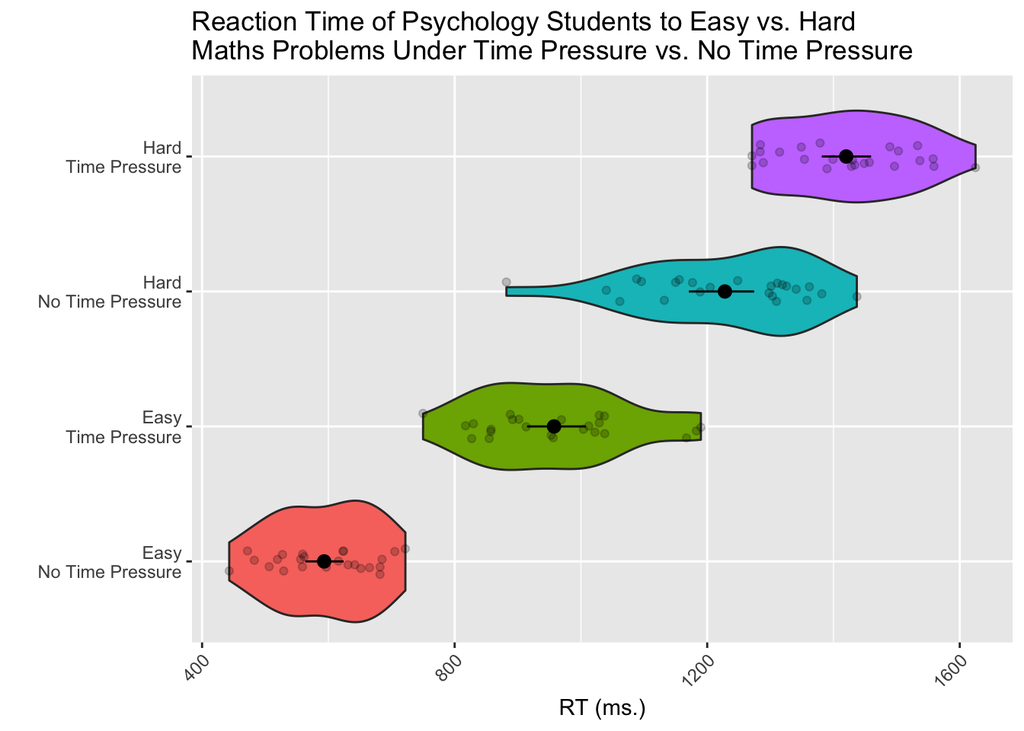

```r
ggplot(data_psych, aes(x = Difficulty:Time_Pressure, y = RT, fill = Difficulty:Time_Pressure)) +
  geom_violin() + geom_jitter(width = .1, alpha = .2) +
  stat_summary(fun.data = mean_cl_boot) + guides(fill = FALSE) +
  theme(axis.text.x = element_text(angle = 45, hjust = 1)) +
  scale_x_discrete(labels = c("Easy\nNo Time Pressure","Easy\nTime Pressure","Hard\nNo Time Pressure", "Hard\nTime Pressure")) +
  labs(x = "", y = "RT (ms.)", title = "Reaction Time of Psychology Students to Easy vs. Hard\nMaths Problems Under Time Pressure vs. No Time Pressure") +
  coord_flip()
```